# **What's the ideal Place to live in Maryland? (based on your needs)**

- Income
- Crime rates
- Weather

Each of these factors contributes to livability and varies significantly across different counties and cities in Maryland.

We're going tackle this problem actively using the process of the data lifecycle. This involves data curating to Exploratory Data analysis and hypothesis testing, using machine learning to help us make an inference, visualize our findings and then finally using our procedure and make an informed decision as to what's the optimal place to live based on your needs.

# Contributions

### Davin Wambogo

- Processed and analyzed county-level violent crime data.
- Created crime rate visualizations and correlation insights.
- Helped format the final tutorial.

### Prasanna Raj

- Focused on city-level crime rates and trends.
- Identified safest areas, explored inter-type correlations, and managed multi-year datasets.
- Worked on Data curation, Data Analysis, and Conclusion portions. Formated the final deliverable.

### Sai Sreeramani

- Initiated the project idea and developed the Exploratory Data Analysis (EDA) procedure.
- Collected and preprocessed income data.
- Led the Machine Learning analysis, refined insights, and contributed to the writing and formatting of the primary analysis report.

### Macbrandon Nden

- Collected and merged average monthly temperature data for Maryland counties into a unified dataset.
- Performed hypothesis testing on temperature data and created a visualization.
- Worked on implementing clustering.

# Data curation

We wanted to gain some insight regarding the factors that contribute to where people decide to live. These factors could include components such as income, crime rate, weather, proximity, and employment rate.

## Income

For income, we collected and gathered data from cities in Maryland from [DataCommons](https://datacommons.org/explore#q=Ranking%20by%20Median%20Individual%20Income%20Maryland%20Cities). We exported the data and extracted the Entity DCID (City identifier), City Name and Median income for each.

```python
import numpy as np
import pandas as pd
import math
from scipy import stats
import matplotlib.pyplot as plt
import seaborn as sns

default_user = {
    "income": 60000,
    "crime": "low",
    "weather": "sunny"
}
income_data = pd.read_csv('Individual_Median_Income_MD_Cities(2020).csv')
metrics = ["Entity DCID", "Entity properties name", "Variable observation value"]
income_df = income_data[metrics]
income_df = income_df.rename(columns={
    "Entity DCID": "DCID",
    "Entity properties name": "City",
    "Variable observation value": "Income"
})
```

[output not shown]

```python
plt.figure(figsize=(10, 6))
plt.title('Distribution of Median Income in Maryland Cities (2020)')
plt.xlabel('Median Income ($)')
plt.ylabel('Frequency')

plt.hist(income_df["Income"], bins=20, color='blue', alpha=0.7)
plt.grid(axis='y', alpha=0.75)

plt.show()
```

[output not shown]

## Crime Rate

**Source:**

Maryland Open Data Portal: Crime by Municipality, 2000–Present

**Description:**

This dataset contains crime statistics reported by municipalities throughout Maryland from 2000 onward. It includes counts of different crime types, total crime counts, and population data for each jurisdiction.

**Transformations:**

These transformations took place depending on the type of graph used.

Crime counts were normalized by population to compute crime rates per 1,000 residents, enabling meaningful comparisons across jurisdictions with varying population sizes.

Data were aggregated by year and crime type to support temporal trend analysis.

Correlation matrices were computed between raw crime counts to identify relationships among crime categories.

Outliers and anomalies in total crime counts were identified and addressed where applicable.

Statistical tests (e.g., t-tests) were performed to compare crime rates and populations between groups of jurisdictions and across years.

Data cleaned for consistency, including handling missing values and standardizing municipality names.

```python
import pandas as pd
import seaborn as sns
import matplotlib.pyplot as plt

url = "https://opendata.maryland.gov/api/views/2p5g-xrcb/rows.csv?accessType=DOWNLOAD"
crime_rate_df = pd.read_csv(url)

# strip extra spaces from all column names
crime_rate_df.columns = crime_rate_df.columns.str.strip()
crime_rate_df
```

|  | JURISDICTION | COUNTY | YEAR | POPULATION | MURDER | RAPE | ROBBERY | AGG. ASSAULT | B & E | LARCENY THEFT | ... | VIOLENT CRIME RATE PERCENT CHANGE PER 100,000 PEOPLE | PROPERTY CRIME RATE PER 100,000 PEOPLE | PROPERTY CRIME RATE PERCENT CHANGE PER 100,000 PEOPLE | MURDER PER 100,000 PEOPLE | RAPE PER 100,000 PEOPLE | ROBBERY PER 100,000 PEOPLE | AGG. ASSAULT PER 100,000 PEOPLE | B & E PER 100,000 PEOPLE | LARCENY THEFT PER 100,000 PEOPLE | M/V THEFT PER 100,000 PEOPLE |
| --- | --- | --- | --- | --- | --- | --- | --- | --- | --- | --- | --- | --- | --- | --- | --- | --- | --- | --- | --- | --- | --- |
| 0 | Galestown | Dorchester | 2008 | 101 | 0 | 0 | 0 | 0 | 0 | 0 | ... | 0.0 | 0.0 | 0.0 | 0.0 | 0.0 | 0.0 | 0.0 | 0.0 | 0.0 | 0.0 |
| 1 | Goldsboro | Caroline | 2014 | 247 | 0 | 0 | 0 | 0 | 0 | 0 | ... | 0.0 | 0.0 | 0.0 | 0.0 | 0.0 | 0.0 | 0.0 | 0.0 | 0.0 | 0.0 |
| 2 | Henderson | Caroline | 1997 | 66 | 0 | 0 | 0 | 0 | 0 | 0 | ... | NaN | 0.0 | NaN | 0.0 | 0.0 | 0.0 | 0.0 | 0.0 | 0.0 | 0.0 |
| 3 | Keedysville | Washington | 1990 | 464 | 0 | 0 | 0 | 0 | 2 | 2 | ... | NaN | 862.1 | NaN | 0.0 | 0.0 | 0.0 | 0.0 | 431.1 | 431.1 | 0.0 |
| 4 | Kitzmiller | Garrett | 1996 | 275 | 0 | 0 | 0 | 0 | 0 | 0 | ... | 0.0 | 0.0 | -100.0 | 0.0 | 0.0 | 0.0 | 0.0 | 0.0 | 0.0 | 0.0 |
| ... | ... | ... | ... | ... | ... | ... | ... | ... | ... | ... | ... | ... | ... | ... | ... | ... | ... | ... | ... | ... | ... |
| 4279 | Woodsboro | Frederick | 2016 | 1185 | 0 | 0 | 0 | 0 | 0 | 0 | ... | -100.0 | 0.0 | -100.0 | 0.0 | 0.0 | 0.0 | 0.0 | 0.0 | 0.0 | 0.0 |
| 4280 | Woodsboro | Frederick | 2017 | 1185 | 0 | 0 | 0 | 1 | 1 | 0 | ... | 84.4 | 84.4 | 84.4 | 0.0 | 0.0 | 0.0 | 84.4 | 84.4 | 0.0 | 0.0 |
| 4281 | Woodsboro | Frederick | 2018 | 1240 | 0 | 0 | 0 | 1 | 0 | 1 | ... | -4.4 | 80.6 | -4.4 | 0.0 | 0.0 | 0.0 | 80.6 | 0.0 | 80.6 | 0.0 |
| 4282 | Woodsboro | Frederick | 2019 | 1240 | 0 | 0 | 0 | 0 | 0 | 0 | ... | -100.0 | 0.0 | -100.0 | 0.0 | 0.0 | 0.0 | 0.0 | 0.0 | 0.0 | 0.0 |
| 4283 | Woodsboro | Frederick | 2020 | 1131 | 0 | 0 | 0 | 0 | 0 | 1 | ... | 0.0 | 88.4 | 88.4 | 0.0 | 0.0 | 0.0 | 0.0 | 0.0 | 88.4 | 0.0 |

4284 rows × 32 columns

## Violent Crime

Source: Maryland Open Data Portal: Crime by County, [1975–Present](https://opendata.maryland.gov/Public-Safety/Violent-Crime-Property-Crime-by-County-1975-to-Pre/jwfa-fdxs/about_data)

Description: This dataset contains yearly violent and property crime rates per 100,000 residents for Maryland counties. It includes disaggregated metrics for major crime types from 1975 to the present.

```python
# Load dataset
url = "https://opendata.maryland.gov/resource/jwfa-fdxs.csv"
crime_df = pd.read_csv(url)

# Clean column names
crime_df.columns = (
    crime_df.columns.str.strip()
    .str.lower()
    .str.replace(' ', '_')
    .str.replace('.', '', regex=False)
    .str.replace(',', '')
)

# Extract county name
crime_df['county'] = crime_df['jurisdiction'].str.replace(r'\s+County$', '', regex=True)

# Drop 'jurisdiction' and reorder columns
cols = crime_df.columns.tolist()
cols.remove('jurisdiction')
cols.insert(0, cols.pop(cols.index('county')))
crime_df = crime_df[cols]

# Filter for most recent year and drop rows with missing values
crime_df_latest = crime_df[crime_df['year'] == crime_df['year'].max()]
crime_df_latest = crime_df_latest.dropna(subset=['county', 'violent_crime_rate_per_100_000_people'])

# Group by county and average numeric columns
county_crime_df = crime_df_latest.groupby('county', as_index=False).mean(numeric_only=True)

# Select relevant crime features
crime_features = [
    'murder_per_100_000_people',
    'rape_per_100_000_people',
    'robbery_per_100_000_people',
    'agg_assault_per_100_000_people',
    'b_e_per_100_000_people',
    'larceny_theft_per_100_000_people',
    'm_v_theft_per_100_000_people'
]

crime_data = county_crime_df.dropna(subset=crime_features).copy()
```

## Weather Dataset

For weather, we used the [NOAA database](https://www.ncei.noaa.gov/access/monitoring/climate-at-a-glance/county/mapping/18/tavg/202401/1/anomaly) to retrieve all Maryland county average temperature in 2024 to help us approach the annual average temperature of each and deter which area is sufficient for the user. Because there wasn't an annual section, we extracted the dataset of all counties per month in 2024 and merged. Each column represents the month and rows of the county.

```python
#importing the average temperature of each county per month
#january
temp_df = pd.read_csv('jan.csv')[['Name', 'Value']].rename(columns={'Name': 'County', 'Value': 'Jan'})
#february
temp_month = pd.read_csv('feb.csv')[['Name', 'Value']].rename(columns={'Name': 'County', 'Value': 'Feb'})

temp_df = pd.merge(temp_df,temp_month, on='County', how='inner')

#march
temp_month = pd.read_csv('march.csv')[['Name', 'Value']].rename(columns={'Name': 'County', 'Value': 'Mar'})

temp_df = pd.merge(temp_df,temp_month, on='County', how='inner')

#april
temp_month = pd.read_csv('april.csv')[['Name', 'Value']].rename(columns={'Name': 'County', 'Value': 'April'})

temp_df = pd.merge(temp_df,temp_month, on='County', how='inner')

#may
temp_month = pd.read_csv('may.csv')[['Name', 'Value']].rename(columns={'Name': 'County', 'Value': 'May'})

temp_df = pd.merge(temp_df,temp_month, on='County', how='inner')

#june
temp_month = pd.read_csv('june.csv')[['Name', 'Value']].rename(columns={'Name': 'County', 'Value': 'June'})

temp_df = pd.merge(temp_df,temp_month, on='County', how='inner')

#july
temp_month = pd.read_csv('july.csv')[['Name', 'Value']].rename(columns={'Name': 'County', 'Value': 'July'})

temp_df = pd.merge(temp_df,temp_month, on='County', how='inner')

#august
temp_month = pd.read_csv('august.csv')[['Name', 'Value']].rename(columns={'Name': 'County', 'Value': 'Aug'})
temp_df = pd.merge(temp_df,temp_month, on='County', how='inner')

#september
temp_month = pd.read_csv('september.csv')[['Name', 'Value']].rename(columns={'Name': 'County', 'Value': 'Sep'})

temp_df = pd.merge(temp_df,temp_month, on='County', how='inner')

#october
temp_month = pd.read_csv('october.csv')[['Name', 'Value']].rename(columns={'Name': 'County', 'Value': 'Oct'})

temp_df = pd.merge(temp_df,temp_month, on='County', how='inner')

#november
temp_month = pd.read_csv('november.csv')[['Name', 'Value']].rename(columns={'Name': 'County', 'Value': 'Nov'})

temp_df = pd.merge(temp_df,temp_month, on='County', how='inner')

#december
temp_month = pd.read_csv('december.csv')[['Name', 'Value']].rename(columns={'Name': 'County', 'Value': 'Dec'})

temp_df = pd.merge(temp_df,temp_month, on='County', how='inner')

# Column for the average annual temperature of each county
month_names = ['Jan', 'Feb', 'Mar', 'April', 'May', 'June','July', 'Aug', 'Sep', 'Oct', 'Nov', 'Dec']
temp_df['Avg_Annual_Temp'] = temp_df[month_names].mean(axis=1)
temp_df.head()
```

[output not shown]

# Exploratory data analysis and Visualization

## Income

Hypothesis Test: Is the User’s Income Significantly Different from the Average? We used a one-sample t-test to evaluate whether the user's income is significantly different from the average income across Maryland cities. Since the optimal city depends on user preferences, we created a default profile for this analysis. The default user's income is set at $60,000.

Null Hypothesis (H₀): The mean income of cities in Maryland equals the user's income. Alternative Hypothesis (H₁): The mean income of cities is different from the user's income.

Result: T-statistic = -20.85 P-value < 0.05

Conclusion: There is strong statistical evidence that the user's income is significantly different from the average income across Maryland cities. The T-statistic of -20.85 indicates that the average city income is far below the user's income—by over 20 standard errors. The P-value < 0.05 confirms that this difference is highly unlikely to be due to random chance.

How this helps the user: This result suggests that the user can afford to live in many cities across Maryland. By comparing the user's income to city-level incomes, we can filter out unaffordable locations and focus recommendations on cities where the cost of living (as proxied by income levels) is within reach. This test supports one part of our goal: helping users find cities that are economically suitable based on their income.

```python
plt.figure(figsize=(10, 6))
plt.title('Distribution of Median Income in Maryland Cities (2020)')
plt.xlabel('Median Income ($)')
plt.ylabel('Frequency')

plt.hist(income_df["Income"], bins=20, color='blue', alpha=0.7)
plt.grid(axis='y', alpha=0.75)

plt.show()
```

[output not shown]

## Crime Rate

Graph based conclusions: https://docs.google.com/document/d/1HR4YUYdQ3BKiC6ECeSTTuvoRRuR7up5Nezd7sdIG7EM/edit?usp=sharing

Note: Jurisdiction means city

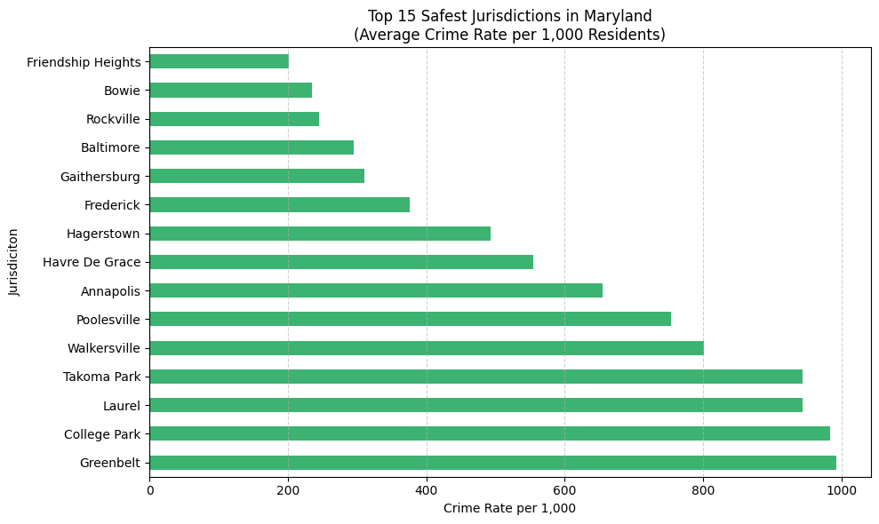

```
note, this includes non lethal crime and minor crimes
Hypothesis Test: Population in Top 15 Safest vs Others
T-statistic: 9.224
P-value: 0.00000 (rounded)
```

```python
from scipy.stats import ttest_ind
import numpy as np
import pandas as pd
import seaborn as sns
import matplotlib.pyplot as plt

crime_start_idx = crime_rate_df.columns.get_loc("POPULATION") + 1
crime_cols = crime_rate_df.columns[crime_start_idx:]

crime_cols = [col for col in crime_cols if pd.api.types.is_numeric_dtype(crime_rate_df[col])]

# Compute crime rate
crime_rate_df["TOTAL CRIME"] = crime_rate_df[crime_cols].sum(axis=1)

# Compute crime rate per 1,000 people
crime_rate_df["Crime Rate per 1,000"] = crime_rate_df["TOTAL CRIME"] / crime_rate_df["POPULATION"] * 1000

avg_crime_rate = crime_rate_df.groupby("JURISDICTION")["Crime Rate per 1,000"].mean().sort_values()

plt.figure(figsize=(10, 6))
avg_crime_rate.head(15).plot(kind="barh", color="mediumseagreen")  # head shows lowest, tail shows highest
plt.title("Top 15 Safest Jurisdictions in Maryland\n(Average Crime Rate per 1,000 Residents)")
plt.xlabel("Crime Rate per 1,000")
plt.ylabel("Jurisdiciton")
plt.gca().invert_yaxis()
plt.grid(axis='x', linestyle='--', alpha=0.6)
plt.tight_layout()
plt.show()

safe_jurisdictions = avg_crime_rate.head(15).index
pop_safe = crime_rate_df[crime_rate_df['JURISDICTION'].isin(safe_jurisdictions)]['POPULATION']

# Other jurisdictions
pop_other = crime_rate_df[~crime_rate_df['JURISDICTION'].isin(safe_jurisdictions)]['POPULATION']

t_stat, p_val = ttest_ind(pop_safe, pop_other, equal_var=False)

print("note, this includes non lethal crime and minor crimes")
print("Hypothesis Test: Population in Top 15 Safest vs Others")
print(f"T-statistic: {t_stat:.3f}")
print(f"P-value: {p_val:.5f}", "(rounded)")
```

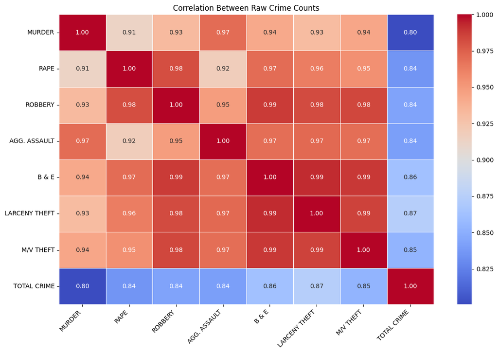

```
Total unique crime pairs compared: 28
Average t-statistic across all unique crime type pairs: -13.877
Average p-value across all unique crime type pairs: 0.05234
```

```python
from scipy.stats import ttest_ind
import numpy as np
import pandas as pd
import seaborn as sns
import matplotlib.pyplot as plt

exclude_cols = ["GRAND TOTAL CRIME", "VIOLENT CRIME TOTAL", "GRAND TOTAL"]

# Filter raw crime columns
raw_crime_cols = [
    col for col in crime_rate_df.columns
    if (col not in ["JURISDICTION", "COUNTY", "YEAR", "POPULATION"] + exclude_cols) and
       pd.api.types.is_numeric_dtype(crime_rate_df[col]) and
       "PER" not in col.upper() and
       "RATE" not in col.upper()
]

# Plot heatmap
plt.figure(figsize=(12, 8))
sns.heatmap(crime_rate_df[raw_crime_cols].corr(), annot=True, cmap="coolwarm", fmt=".2f", linewidths=0.5)
plt.title("Correlation Between Raw Crime Counts")
plt.xticks(rotation=45, ha='right')
plt.yticks(rotation=0)
plt.tight_layout()
plt.show()

t_stats = []
p_values = []

for i in range(len(raw_crime_cols)):
    for j in range(i + 1, len(raw_crime_cols)):
        col1 = raw_crime_cols[i]
        col2 = raw_crime_cols[j]

        subset = crime_rate_df[[col1, col2]].dropna()

        if len(subset) > 2:
            t_stat, p_val = ttest_ind(subset[col1], subset[col2], equal_var=False)
            t_stats.append(t_stat)
            p_values.append(p_val)

avg_t_stat = np.mean(t_stats)
avg_p_value = np.mean(p_values)

print(f"Total unique crime pairs compared: {len(p_values)}")
print(f"Average t-statistic across all unique crime type pairs: {avg_t_stat:.3f}")
print(f"Average p-value across all unique crime type pairs: {avg_p_value:.5f}")
```

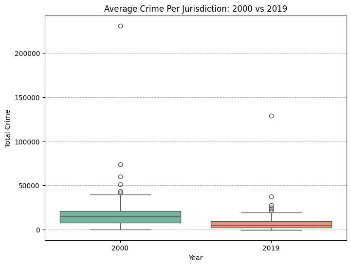

```
T-statistic: 4.900
P-value: 0.00000 (rounded)
```

```python
from scipy.stats import ttest_ind
import pandas as pd
import seaborn as sns
import matplotlib.pyplot as plt

crime_2000 = crime_rate_df[crime_rate_df["YEAR"] == 2000]["TOTAL CRIME"]
crime_2019 = crime_rate_df[crime_rate_df["YEAR"] == 2019]["TOTAL CRIME"]

# combine into one DataFrame
combined_df = pd.concat([
    crime_2000.to_frame().assign(Year="2000"),
    crime_2019.to_frame().assign(Year="2019")
])

plt.figure(figsize=(8, 6))
sns.boxplot(data=combined_df, x="Year", y="TOTAL CRIME", hue="Year", palette="Set2")
plt.title("Average Crime Per Jurisdiction: 2000 vs 2019")
plt.ylabel("Total Crime")
plt.grid(True, linestyle='--', axis='y')

plt.legend([], [], frameon=False)

plt.show()

t_stat, p_val = ttest_ind(crime_2000, crime_2019, equal_var=False)

# Print hypothesis testing
print(f"T-statistic: {t_stat:.3f}")
print(f"P-value: {p_val:.5f}", "(rounded)")
```

## Weather

We conducted a t-test for each county temperature. The test measured if the average monthly temperature is an adequate temperature. Since we're trying to find an bench mark as to what the user might find ideal. I chose 60°F, which is fairly a decent weather. Below is how we conducted our hypothesis test

```python
results = []
for idx, row in temp_df.iterrows():
    county = row['County']
    temps = row[['Jan', 'Feb', 'Mar', 'April', 'May', 'June','July', 'Aug', 'Sep', 'Oct', 'Nov', 'Dec']].values.astype(float)
    t_stat, p_val = stats.ttest_1samp(temps, popmean=60)
    results.append({
        'County': county,
        'Sample Mean': temps.mean(),
        'Sample SD': temps.std(ddof=1),
        'T-statistic': t_stat,
        'P-value': math.floor(p_val),
    })

results_df = pd.DataFrame(results)
results_df.head()
```

[output not shown]

```python
plt.figure(figsize=(14, 6))
sns.barplot(x='County', y='Avg_Annual_Temp', data=temp_df)

plt.axhline(y=60, color = 'red', linestyle='-', label='60°F')

plt.title('Average Annual Temperature by County')
plt.xlabel('County')
plt.ylabel('Average Temperature (°F)')
plt.xticks(rotation=90)
plt.ylim(50, 70)
plt.legend()
plt.show()
```

[output not shown]

As such this metric can help me find an optimal temperature by finding the closest temperature to their given temperature.

# Primary analysis

We utilize this unsupervised machine learning technique to address the inherent complexity of simultaneously evaluating multiple critical factors such as income, crime rates, and weather conditions without relying on subjective judgments or labeled data.

K-Means clustering excels at discovering underlying patterns within complex, multi-dimensional datasets. By standardizing our chosen features (median income, violent crime rates, and average annual temperatures), we ensure all variables are given equal consideration. K-Means then systematically identifies clusters based on the similarities and dissimilarities among regions, generating distinct quality-of-life profiles. Each resulting cluster encapsulates a balanced combination of the factors, naturally grouping regions into meaningful categories such as "high income + moderate crime + warm climate" or "moderate income + low crime + cool climate."

Critically, clustering simplifies the task of personalized recommendation. When a user specifies their preferences, for instance, desiring high income opportunities, low crime, and mild weather, these preferences are translated into the same standardized scale used for clustering. K-Means efficiently identifies the cluster whose centroid most closely matches the user's criteria, instantly narrowing down potential regions.

Once clusters are created, we can retrieve the top regions by selecting those points closest to the centroid matching the user's preferences, ensuring that the recommendations are directly aligned with what matters most to each user. Subsequently, regions within this targeted cluster can be precisely ranked according to their proximity to the user's specific preferences, providing clear, actionable recommendations.

This approach is computationally efficient, as clustering only needs to be performed once, after which individual user queries require minimal computational resources. It also ensures transparency and interpretability, as each cluster can be described clearly and intuitively to end-users, aiding their decision-making process. Additionally, visualizing the clusters through techniques such as PCA plots further strengthens user engagement and understanding, making complex multi-dimensional data accessible and easily comprehensible.

In essence, employing K-Means clustering aligns seamlessly with our project's goal of providing data-driven, user-centric recommendations. It effectively addresses the multidimensional nature of choosing optimal living locations and delivers personalized, transparent, and reliable insights to our users.

```python
from sklearn.preprocessing import StandardScaler
from sklearn.cluster import KMeans
import pandas as pd
import matplotlib.pyplot as plt
import seaborn as sns

merged_df = (
    income_df.rename(columns={'City': 'Region'})
    .merge(crime_df[['county', 'violent_crime_rate_per_100_000_people']].rename(columns={'county': 'Region'}), on='Region')
    .merge(temp_df[['County', 'Avg_Annual_Temp']].rename(columns={'County': 'Region'}), on='Region')
)

merged_df = merged_df.dropna()
```

```python
X = merged_df[['Income', 'violent_crime_rate_per_100_000_people', 'Avg_Annual_Temp']]

scaler = StandardScaler()
X_scaled = scaler.fit_transform(X)

kmeans = KMeans(n_clusters=3, random_state=42)
merged_df['Cluster'] = kmeans.fit_predict(X_scaled)
```

```python
import matplotlib.pyplot as plt
import seaborn as sns

plt.figure(figsize=(10, 6))
sns.scatterplot(
    data=merged_df,
    x='Income',
    y='violent_crime_rate_per_100_000_people',
    hue='Cluster',
    palette='Set2',
    s=100
)
plt.title('K-Means Clustering of Maryland Regions')
plt.xlabel('Median Income ($)')
plt.ylabel('Violent Crime Rate per 100,000 People')
plt.tight_layout()
plt.show()

cluster_summary = merged_df.groupby('Cluster')[['Income', 'violent_crime_rate_per_100_000_people', 'Avg_Annual_Temp']].mean()
```

[output not shown]

```python
# User-defined preferences
user = pd.DataFrame([[60000, 150, 65]], columns=X.columns)

user_scaled = scaler.transform(user)

# Find nearest cluster
closest_cluster = kmeans.predict(user_scaled)[0]

# Show top recommended regions based off cluster
rec = merged_df[merged_df['Cluster'] == closest_cluster]
rec['Distance'] = ((X_scaled[merged_df['Cluster'] == closest_cluster] - user_scaled) ** 2).sum(axis=1)
rec = rec.sort_values('Distance')

display(rec[['Region', 'Income', 'violent_crime_rate_per_100_000_people', 'Avg_Annual_Temp']].head(5))
```

[output not shown]

# Insights and Conclusions

After going through the project, both someone new to the topic and someone more familiar with it would likely walk away having learned something valuable. For a reader who doesn't have a background in crime statistics, income data, or population trends, the project does a good job breaking things down and explaining how different factors like overall crime, violent crime, income levels, and even weather can influence where people choose to live. It makes a complex topic feel approachable, especially with the help of clear graphs and real world examples. On the other hand, someone who already knows a bit about these issues would still find the analysis interesting, particularly in how the project compares different Maryland areas and highlights the safest ones. Instead of just listing facts, it connects the dots and shows how different data correlations interact for crime, weather and income, giving a deeper look at what makes a certain area desirable. Whether you're new to the subject or already informed, the project offers useful insights into how safety, wealth, and environment shape where people live, as well as the overall quality of these areas.